# IMDB

Johanna and Lance

May 2nd, 2023

# Introducing, The Data!

[Link To The Data We Used](https://www.kaggle.com/datasets/karkavelrajaj/imdb-top-250-movies)

One of the most popular topics in the entertainment industry are movies, especially when it flares a debate on how the movies should be ranked. These conversations can be supported with genre, successful directors, and even just personal bias. In the data, we analyze the top 250 movies on IMDB and what patterns and trends lie among the variables. This data set was created 2 months ago with the intention of allowing others to access it and “…do a lot of things as mentioned below

- Dataset Walkthrough
- Understanding Dataset Hierarchy
- Data Preprocessing
- Exploratory Data Analysis
- Data Visualization
- Making Recommendation System

This is a list of some of that things that you can do on this dataset. It’s not definitely limited to the one that is mentioned there but a lot more other things can also be done.”

```r
imdb <- read.csv("movies.csv")
glimpse(imdb)
```

```
## Rows: 250
## Columns: 22
## $ rank           <int> 1, 2, 3, 4, 5, 6, 7, 8, 9, 10, 11, 12, 13, 14, 15, 16, …
## $ movie_id       <chr> "tt0111161", "tt0068646", "tt0468569", "tt0071562", "tt…
## $ title          <chr> "The Shawshank Redemption", "The Godfather", "The Dark …
## $ year           <int> 1994, 1972, 2008, 1974, 1957, 1993, 2003, 1994, 2001, 1…
## $ link           <chr> "https://www.imdb.com/title/tt0111161", "https://www.im…
## $ imbd_votes     <chr> "2,711,075", "1,882,829", "2,684,051", "1,285,350", "80…
## $ imbd_rating    <dbl> 9.3, 9.2, 9.0, 9.0, 9.0, 9.0, 9.0, 8.9, 8.8, 8.8, 8.8, …
## $ certificate    <chr> "R", "R", "PG-13", "R", "Approved", "R", "PG-13", "R", …
## $ duration       <chr> "2h 22m", "2h 55m", "2h 32m", "3h 22m", "1h 36m", "3h 1…
## $ genre          <chr> "Drama", "Crime,Drama", "Action,Crime,Drama", "Crime,Dr…
## $ cast_id        <chr> "nm0000209,nm0000151,nm0348409,nm0006669,nm0000317,nm00…
## $ cast_name      <chr> "Tim Robbins,Morgan Freeman,Bob Gunton,William Sadler,C…
## $ director_id    <chr> "nm0001104", "nm0000338", "nm0634240", "nm0000338", "nm…
## $ director_name  <chr> "Frank Darabont", "Francis Ford Coppola", "Christopher …
## $ writer_id      <chr> "nm0000175,nm0001104", "nm0701374,nm0000338", "tt046856…
## $ writer_name    <chr> "Stephen King,Frank Darabont", "Mario Puzo,Francis Ford…
## $ storyline      <chr> "Over the course of several years, two convicts form a …
## $ user_id        <chr> "ur16161013,ur15311310,ur0265899,ur16117882,ur1898687,u…
## $ user_name      <chr> "hitchcockthelegend,Sleepin_Dragon,EyeDunno,alexkolokot…
## $ review_id      <chr> "rw2284594,rw6606154,rw1221355,rw1822343,rw1288098,rw03…
## $ review_title   <chr> "Some birds aren't meant to be caged.,An incredible mov…
## $ review_content <chr> "The Shawshank Redemption is written and directed by Fr…
```

# Where Are The Keys?

### This is a list of all the variable names and what they are.

- **rank - Movie Rank as per IMDB rating**
- movie_id - Movie ID
- **title - Name of the Movie**
- **year - Year of Movie release**
- link - URL for the Movie page in IMDB
- imdb_votes - Number of people who voted for the IMDB rating
- **imdb_rating - Rating of the Movie**
- **certificate - Movie Certification**
- duration - Duration of the Movie
- **genre - Genre of the Movie**
- cast_id - ID of the cast member who have worked on the Movie
- cast_name - Name of the cast member who have worked on the Movie
- director_id - ID of the director who have directed the Movie
- **director_name - Name of the director who have directed the Movie**
- writer_id - ID of the writer who have wrote script for the Movie
- writer_name - Name of the writer who have wrote script for the Movie
- storyline - Storyline of the Movie
- user_id - ID of the user who wrote review for the Movie
- user_name - Name of the user who wrote review for the Movie
- review_id - ID of the user review
- review_title - Short review
- review_content - Long review

As you can see, there are a lot of variables right now and some of it is difficult to use and would not help us with our main question so let’s clean!

# Filtering

```r
imdb_1 <- imdb %>%
  select(rank, title, year, imbd_rating, certificate, genre, director_name)
glimpse(imdb_1)
```

```
## Rows: 250
## Columns: 7
## $ rank          <int> 1, 2, 3, 4, 5, 6, 7, 8, 9, 10, 11, 12, 13, 14, 15, 16, 1…
## $ title         <chr> "The Shawshank Redemption", "The Godfather", "The Dark K…
## $ year          <int> 1994, 1972, 2008, 1974, 1957, 1993, 2003, 1994, 2001, 19…
## $ imbd_rating   <dbl> 9.3, 9.2, 9.0, 9.0, 9.0, 9.0, 9.0, 8.9, 8.8, 8.8, 8.8, 8…
## $ certificate   <chr> "R", "R", "PG-13", "R", "Approved", "R", "PG-13", "R", "…
## $ genre         <chr> "Drama", "Crime,Drama", "Action,Crime,Drama", "Crime,Dra…
## $ director_name <chr> "Frank Darabont", "Francis Ford Coppola", "Christopher N…
```

Much better! Now that we have data that is more manageable, let’s explore some questions that arise when viewing it!

# Questions? or Inquiries?

**Main Question:**

What are some key similarities and trends between the top 250 IMDB movies?

**Side Questions:**

What are the top 10 movies of this data set?

What are the oldest and the newest movies in this set?

What is the best movie in each decade?

How many movies were made in each decade?

Was there a correlation between the year it was released and how it was rated?

How many movies were in each certificate type?

What were the best genres of movies?

Who were the most successful directors?

# Top Tops?

The first thing we are going to take a look at are the top ten in this set based on IMDB rank.

```r
head(imdb_rt, 10)
```

```
##    rank                                             title
## 1     1                          The Shawshank Redemption
## 2     2                                     The Godfather
## 3     3                                   The Dark Knight
## 4     4                             The Godfather Part II
## 5     5                                      12 Angry Men
## 6     6                                  Schindler's List
## 7     7     The Lord of the Rings: The Return of the King
## 8     8                                      Pulp Fiction
## 9     9 The Lord of the Rings: The Fellowship of the Ring
## 10   10                    The Good, the Bad and the Ugly
```

# Do You Like Them Older Or Newer?

The next thing we are going to look at are the oldest movies that are included in this list, this also allows us to see what the distribution of the ranks are.

```r
decadeimdb
```

```
##    rank year
## 1   128 1921
## 2   195 1924
## 3   177 1925
## 4   187 1926
## 5   115 1927
## 6   208 1928
## 7    52 1931
## 8    96 1931
## 9   242 1934
## 10   47 1936
```

```r
rankedecade
```

```
##    rank year
## 1    47 1936
## 2    52 1931
## 3    96 1931
## 4   115 1927
## 5   128 1921
## 6   177 1925
## 7   187 1926
## 8   195 1924
## 9   208 1928
## 10  242 1934
```

Let’s do the same thing for the newer movies and then graph the old and the new, no discrimination!

```r
ldecadeimdb
```

```
##    rank year
## 1   113 2022
## 2   152 2021
## 3   234 2021
## 4   107 2020
## 5   130 2020
## 6    34 2019
## 7    75 2019
## 8    78 2019
## 9   123 2019
## 10  178 2019
```

```r
rankedecade2
```

```
##    rank year
## 1    34 2019
## 2    75 2019
## 3    78 2019
## 4   107 2020
## 5   113 2022
## 6   123 2019
## 7   130 2020
## 8   152 2021
## 9   178 2019
## 10  234 2021
```

And now let’s graph!

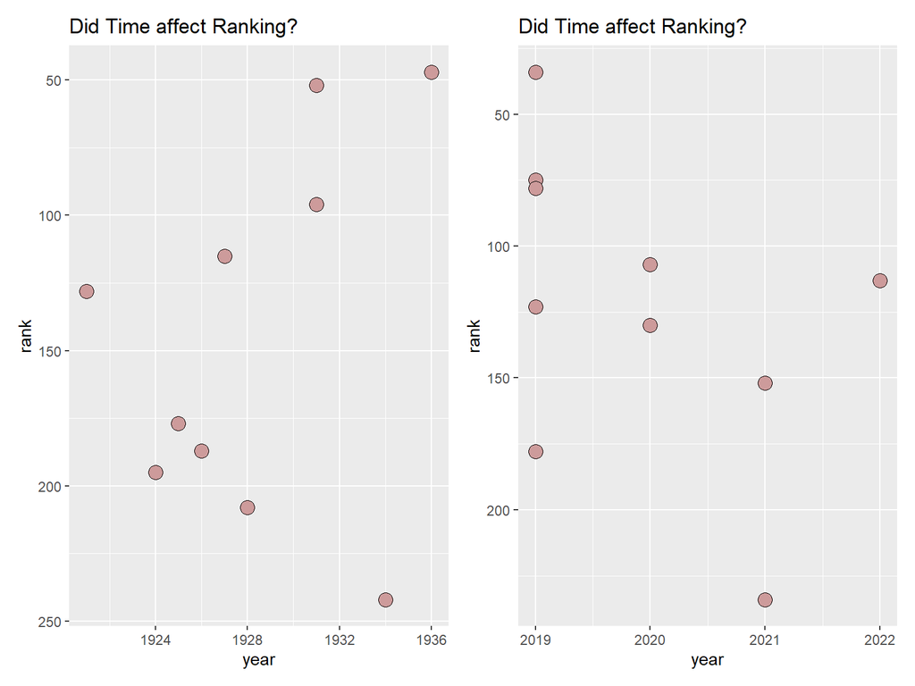

```r
plottr + plottr2
```

# How Decade-nt

Now, 250 movies is definitely a much smaller group in the grand scheme of cinema. However, what if we broke it up into subcategories for each decade? Two interesting sets of data that we could then look at are the best rated movie from each decade and also how many movies were produced during that period.

```r
kable(list(byear, ntable))
```

| rank | title | year | imbd_rating |
| --- | --- | --- | --- |
| 115 | Metropolis | 1927 | 8.3 |
| 47 | Modern Times | 1936 | 8.5 |
| 21 | It’s a Wonderful Life | 1946 | 8.6 |
| 5 | 12 Angry Men | 1957 | 9.0 |
| 10 | The Good, the Bad and the Ugly | 1966 | 8.8 |
| 2 | The Godfather | 1972 | 9.2 |
| 15 | Star Wars: Episode V - The Empire Strikes Back | 1980 | 8.7 |
| 1 | The Shawshank Redemption | 1994 | 9.3 |
| 3 | The Dark Knight | 2008 | 9.0 |
| 14 | Inception | 2010 | 8.8 |
| 107 | Hamilton | 2020 | 8.4 |

| n_movies | decades |
| --- | --- |
| 6 | 1920 |
| 7 | 1930 |
| 12 | 1940 |
| 23 | 1950 |
| 18 | 1960 |
| 19 | 1970 |
| 27 | 1980 |
| 42 | 1990 |
| 48 | 2000 |
| 43 | 2010 |
| 5 | 2020 |

Let’s see what these graphs look like!

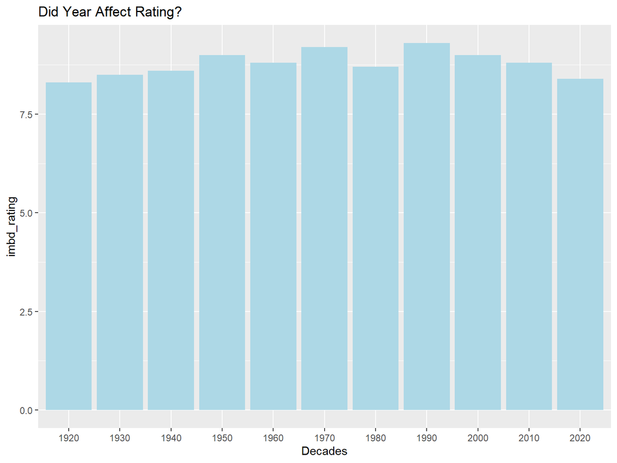

```r
ggplot(data = headvec, aes(x= factor(year, labels = as.character(seq(1920, 2020, by = 10))), y = imbd_rating)) +
  geom_col(fill = "lightblue") +
  xlab("Decades") +
  ggtitle("Did Year Affect Rating?")
```

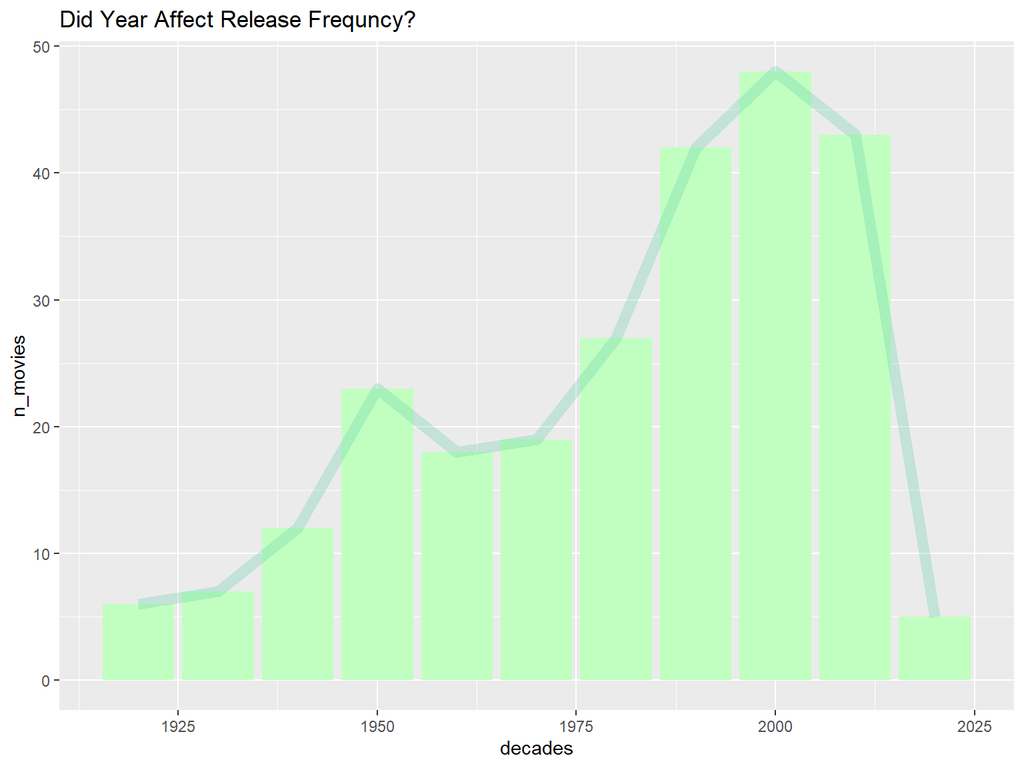

```r
ggplot(data = ntable, aes(x = decades, y = n_movies)) +
  geom_bar(stat = "identity", fill = "darkseagreen1") +
  geom_line(lwd = 3, alpha = 0.3, color = "mediumaquamarine") +
  ggtitle("Did Year Affect Release Frequncy?")
```

# Ranking Over The Years

Did the time period have an effect on the ranking that a movie got on average? Let’s make a graph that allows us to explore this further.

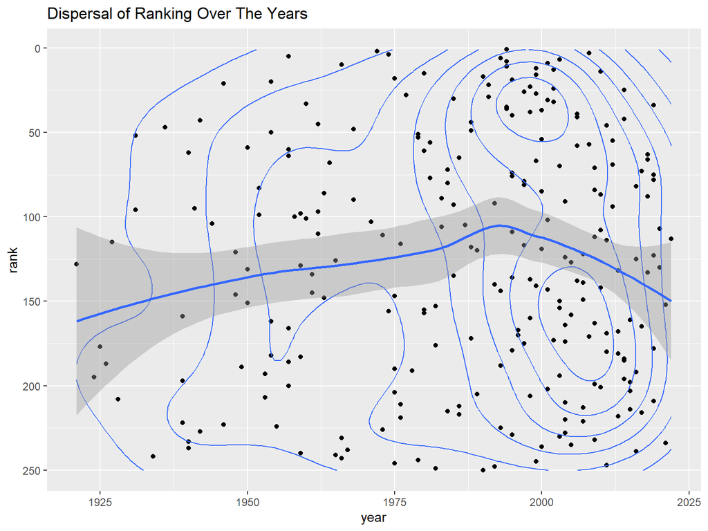

```r
ggplot(data = imdb_1, aes(x = year, y = rank))+
  geom_point() +
  geom_density2d() +
  geom_smooth() +
  scale_y_reverse() +
  ggtitle("Dispersal of Ranking Over The Years")
```

# Best Movie Award Goes To..

When it comes to the certification of these movies we can first count up how many movies were in each category.

```r
y2
```

```
##         Var1 Freq
## 1               1
## 2        13+    1
## 3        18+    1
## 4   Approved   14
## 5          G   19
## 6         GP    1
## 7  Not Rated   24
## 8     Passed   16
## 9         PG   37
## 10     PG-13   35
## 11         R   97
## 12     TV-MA    1
## 13     TV-PG    1
## 14   Unrated    1
## 15         X    1
```

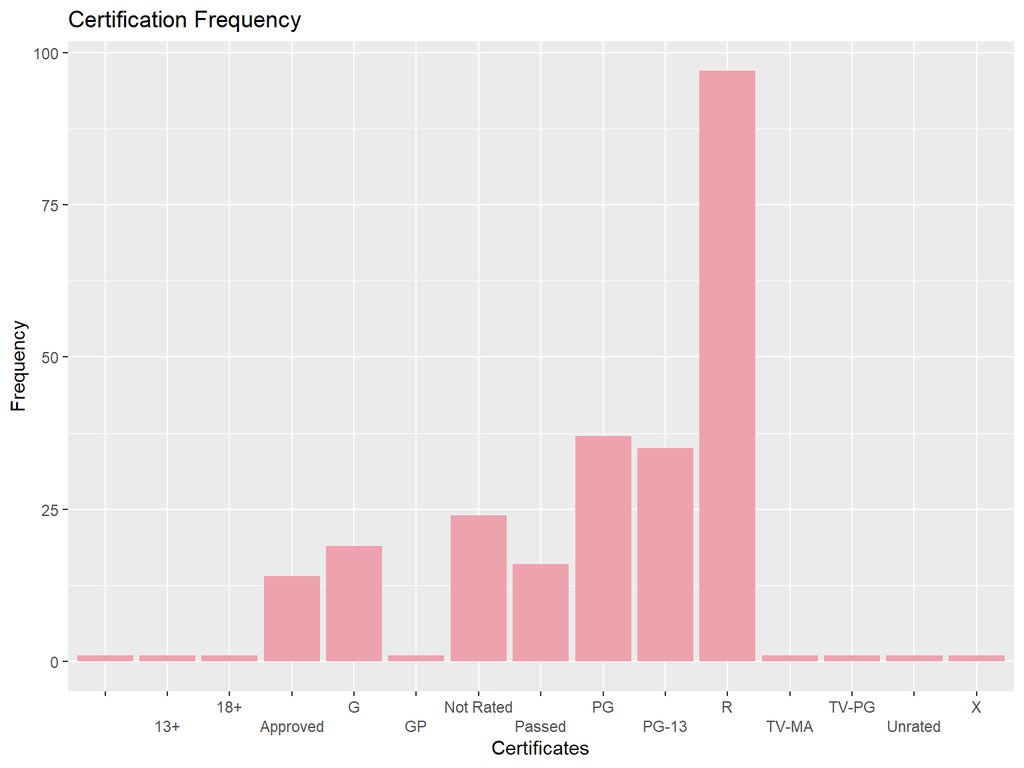

```r
certified
```

# What’s Your Type?

```r
g2
```

```
##                           Var1 Freq
## 1             Action,Adventure    2
## 2      Action,Adventure,Comedy    1
## 3       Action,Adventure,Drama    5
## 4     Action,Adventure,Fantasy    5
## 5     Action,Adventure,Mystery    1
## 6      Action,Adventure,Sci-Fi    5
## 7       Action,Biography,Drama    3
## 8          Action,Comedy,Crime    1
## 9        Action,Comedy,Romance    1
## 10          Action,Crime,Drama    5
## 11                Action,Drama    2
## 12        Action,Drama,Mystery    2
## 13         Action,Drama,Sci-Fi    3
## 14          Action,Drama,Sport    1
```

[output cut: 90 more lines]

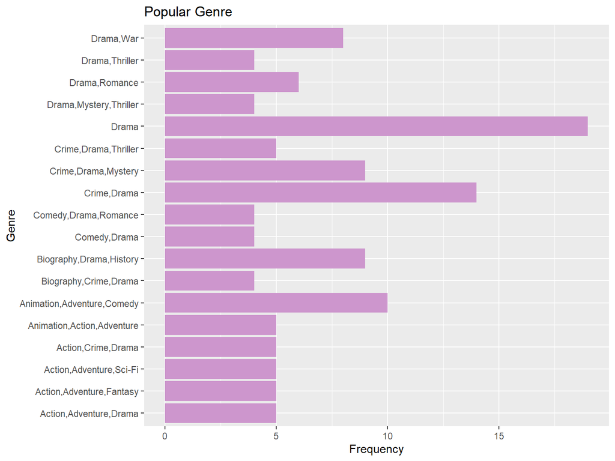

```r
genrep
```

# The GOATs

Who are the directors with the most Ws? Let’s see!

```r
directp <- ggplot(data = d3, aes(x = Freq, y = Var1)) +
  geom_bar(stat = "identity", fill = "plum") +
  xlab("Frequency") +
  ylab("Directors") +
  ggtitle("Popular Directors")
```

```r
d3
```

```
##                    Var1 Freq
## 1        Akira Kurosawa    7
## 2      Alfred Hitchcock    6
## 3          Billy Wilder    5
## 4       Charles Chaplin    5
## 5     Christopher Nolan    7
## 6        Clint Eastwood    3
## 7         David Fincher    3
## 8  Francis Ford Coppola    3
## 9           Frank Capra    3
## 10       Hayao Miyazaki    4
## 11       Ingmar Bergman    3
## 12        James Cameron    3
## 13      Martin Scorsese    7
## 14        Peter Jackson    3
## 15    Quentin Tarantino    5
## 16         Ridley Scott    3
## 17         Sergio Leone    4
## 18      Stanley Kubrick    7
## 19     Steven Spielberg    7
```

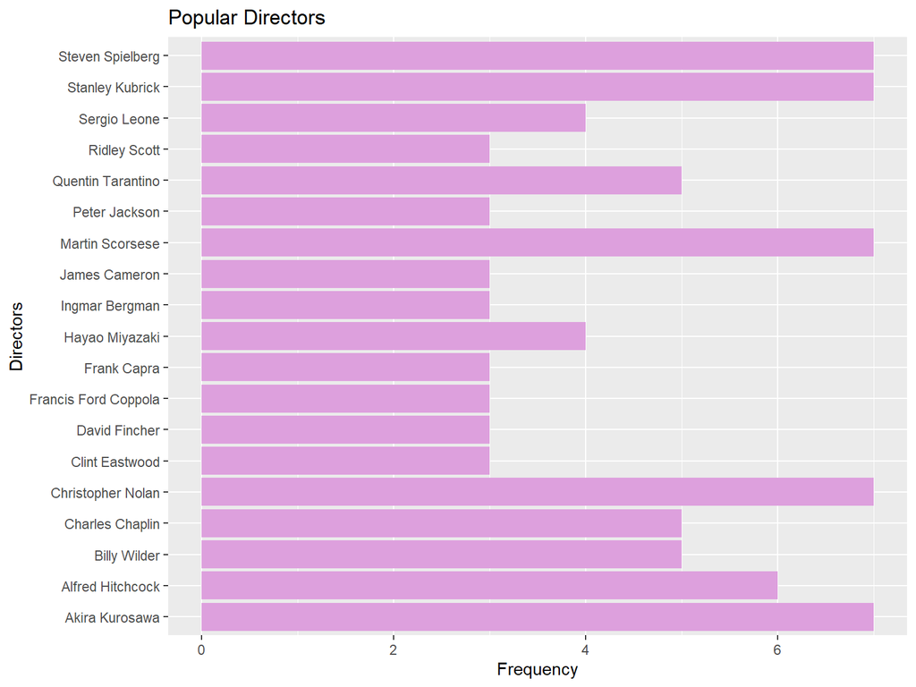

```r
directp
```

# Summary

Some of the limitations that we experienced while working on this project that we could do further observations on include: using other databases such as rotten tomatoes and metascore, we could either expand our data to the top 500 movies or get information on the bottom 250 movies.

The End :)